# Measuring crime, victims of crime, and classifying crime

CRIM 100

## Crime classifications

- Official typologies
- Scientific or academic typologies

# Official crime typologies

## Uniform Crime Reporting Survey (UCR)

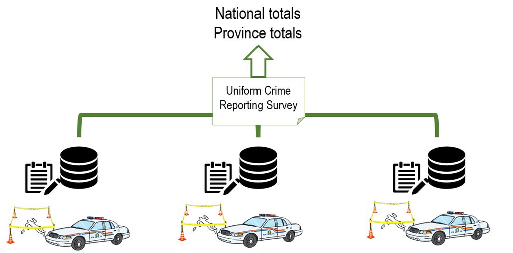

## UCR History

- Used by the Canadian Centre for Justice Statistics (CCJS) to collect police-reported crime statistic
- Operating in Canada since 1962
- Provides key information for crime analysis, resource planning and program development
- Has 2 data collection instruments:
  - UCR 1: collects aggregate data
  - UCR 2: COllects micrdata on events and participants (referred to as the incident-based survey)

## UCR Crime Typology

- Crimes Against the Person
- Crimes Against Property
- Other criminal Code Violations
- Controlled Drugs And Substances Act
- Other Federal Statute Violations
- Criminal Code Traffic Violations

## Aggregated Data vs Disaggregated Data

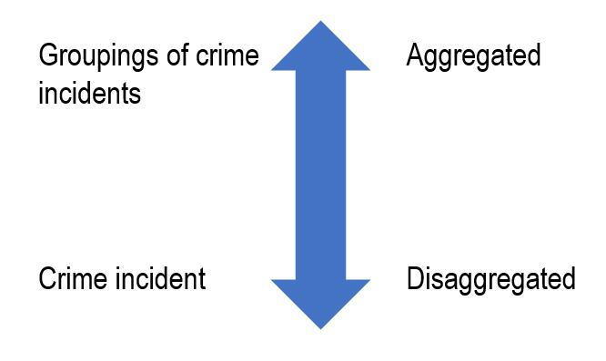

## Question:

What are some of the disavantages and advantages of using aggregated vs disaggregated data?

## UCR Crime Typology

- *Crimes Against the Person:* Unlawful acts perpetrated with the use or threat of use of force and/or result in freedom deprivation
- *Crimes Against Property:* Unlawful acts perpetrated with the intent of gaining property by without the use or threat of violence.
- *Other criminal Code Violations:* Neither violent nor property-related offences.
- *Controlled Drugs And Substances Act:* Unlawful acts related to supply and/or possession of prohibited drugs.

## Violations Causing Death

- Murder 1st Degree
- Murder 2nd Degree
- Manslaughter

## Homicide

- Culpable homicide
- Non-culpable homicide

## Measuring crime

- Crime counts – volume of crime
- Crime rates – risk of crime
- Location quotients of crime – crime specialization

# Limitations of Official Crime statistics

## Reporting and Recording Choices

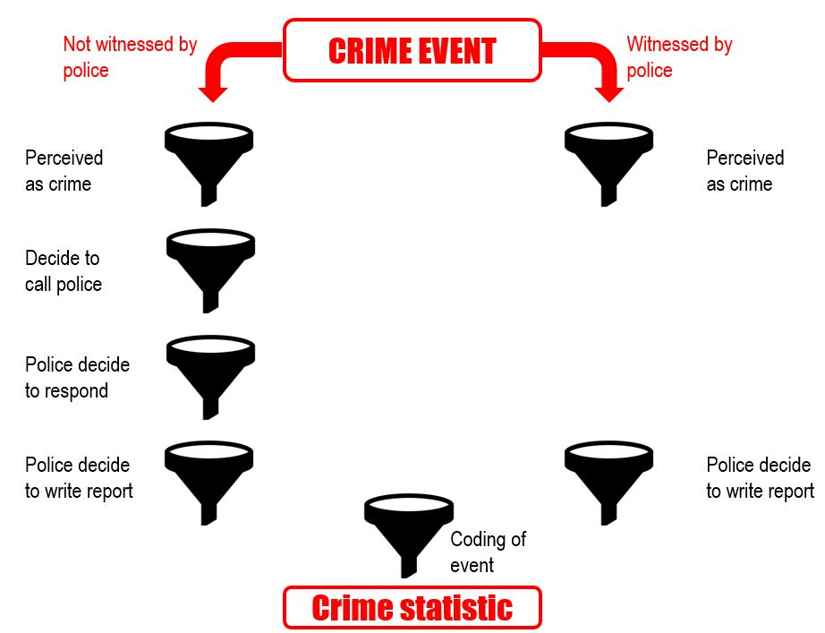

## The Crime Funnel

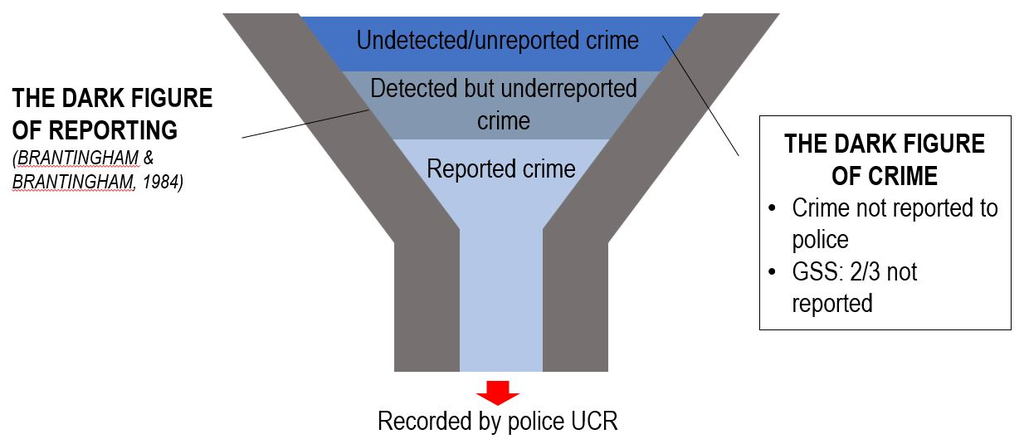

## Constructionist Perspective

- Focuses on the production of crime statistics
- Notes how police practices affect crime stats (choosing calls, exercising discretion & policing styles)

## Homicide: Best indicator

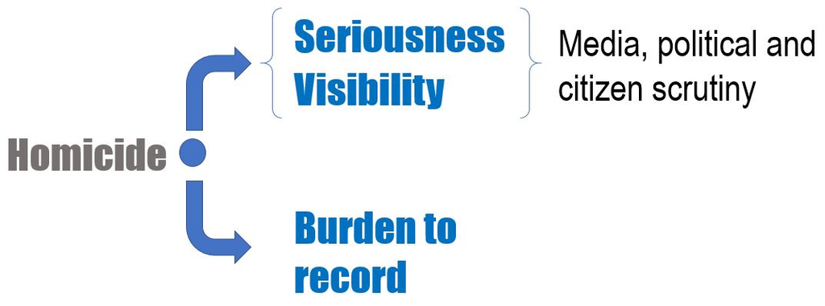

## Question:

What other crimes do you think have a relatively low dark figure?

## Differences in US Homicides by Sources (Riedel, 1999)

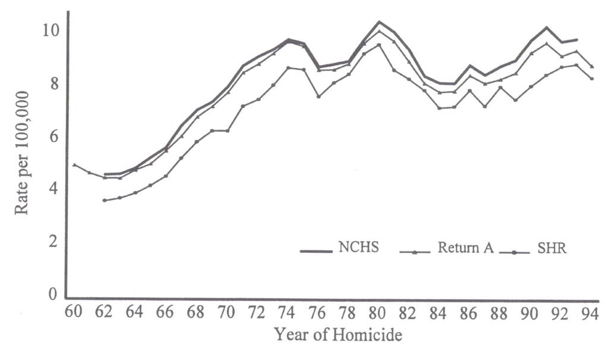

## Differences in Canadian Homicides by Sources (Gabor et al, 2002)

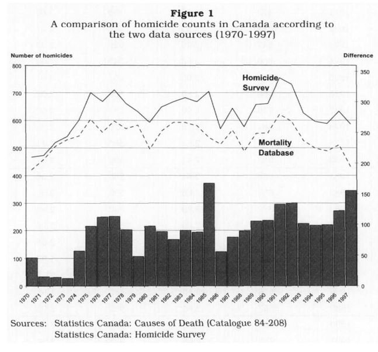

## Quantitative Crime Research

[figure not shown]

## Benefits of victimization surveys (Evans & Leger, 1979)

- Overcome dark figure problem
- Impact of crime
- Victimization risk
- Victims’ perceptions

## Canada’s victimization surveys

- General Social Survey (GSS)
- Violence against women survey (VAWSS)
- International Crime Victims Survey

## Victimology

- Sub-field of criminology
- Focused on victims
  - VOR
  - Victim’s experience
  - CJS

## Evolution of victimology

- Early theoretical focus:
  - How do victims contribute to crime?
- Victim blaming criticisms
  - Preventive aim cited as a response
  - Ultimately more applied approach was adopted that focused on:
    - Assistance
    - Victims’ rights

## Victim Centered Theories

- Victim Precipitation Theory
- Lifestyle Theory
- Routine Activity Theory

## Victim Precipitation Theory

Focused on explaining how victims’ actions or inactions lead to their victimization

[figure not shown]

## Lifestyle Theory

- Its main premise is that differences in risks of victimization are associated with differences in lifestyles.
  - Equivalent group hypothesis
  - Proximity hypothesis
  - Deviant place hypothesis

## Routine Activity Theory

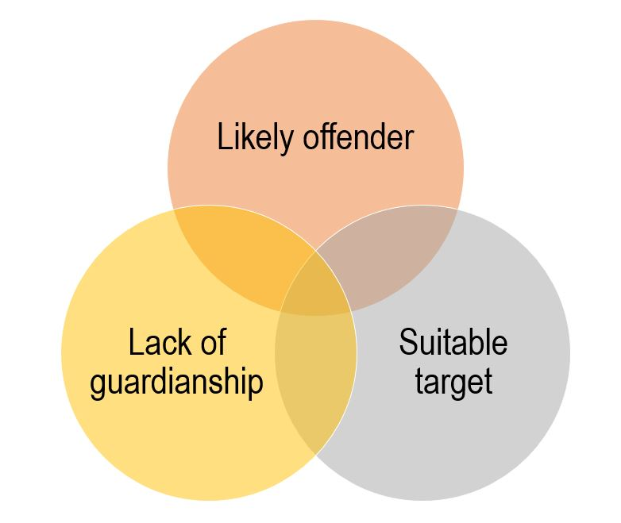

# Academic Typologies

## Historical Roots

- Lombroso’s (1876) 6 types offenders
  - The born criminal
  - The epileptic criminal
  - The criminal of irresistible passion
  - The insane or feebleminded criminal
  - The occasional criminal
  - The persistent and non-abnormal type of criminal

## The Formulation of Typologies Requires

- Maximization of intra-group homogeneity
- Maximization inter-group heterogeneity
- Using defined attributes as discrimination criteria
- Theoretical basis
- Systematic observation and evaluation
  - Qualitative or quantitative methods

## Grouping Criteria

- Victim characteristics
- Offenders characteristic
- Nature of victim-offender relationship
- Event circumstances and characteristics
- Motivation

## Homicides

- Parricide
- Infanticide
- Feminicide
- Spree homicide
- Serial homicide

## Fesbach’s (1964) typology

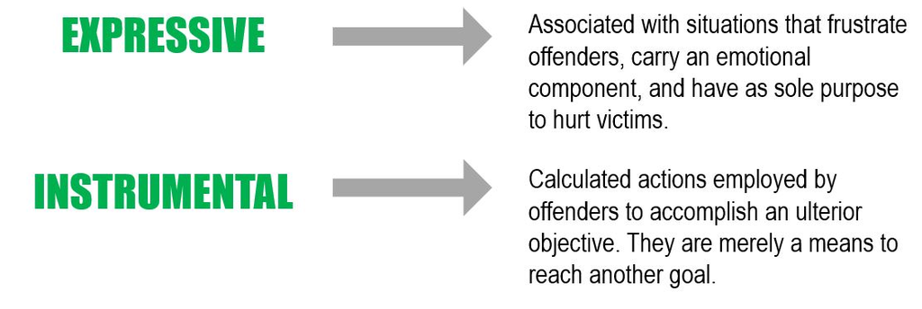

## Sexual Murder typologies

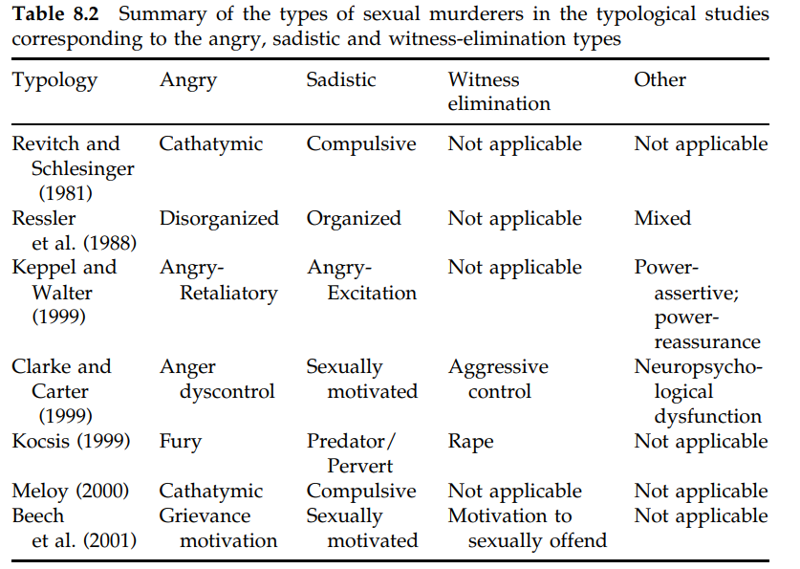

## Policy Benefits and Uses

- Risk levels
- Treatment
- Controls for targeted offender groups

# Important content

## Key concepts and terms

- Uniform Crime Reporting Survey (UCR)
- General Social Survey (GSS)
- Murder 1st Degree
- Murder 2nd Degree
- Manslaughter
- Culpable homicide
- Non-culpable homicide
- Crime counts
- Crime rates
- Location quotients of crime
- The Crime Funnel
- The dark figure of crime
- The dark figure of reporting
- COnstructionist perspective
- Spree homicide
- Serial homicide
- Expressive and instrumental crimes
- Victimology
- Victim Precipitation Theory
- Lifestyle Theory
- Routine Activity Theory